## Introduction

**Goal**: by the end of this lab, you will be able to use `colorbrewer` and `ggthemes` to customize the look of your visualization.

### Setting up

For this lab, we’re going to be using the `ToothGrowth` dataset, which is one of the example datasets included in `R`. It contains data on how fast guinea pigs’ teeth grow if you give them vitamin C supplements in various forms and at various doses. You can learn more about this dataset by typing `?ToothGrowth` at the console.

Let’s take a look:

```r
library(tidyverse)
glimpse(ToothGrowth)
```

```
## Rows: 60
## Columns: 3
## $ len  <dbl> 4.2, 11.5, 7.3, 5.8, 6.4, 10.0, 11.2, 11.2, 5.2, 7.0, 16.5, 16.5,…
## $ supp <fct> VC, VC, VC, VC, VC, VC, VC, VC, VC, VC, VC, VC, VC, VC, VC, VC, V…
## $ dose <dbl> 0.5, 0.5, 0.5, 0.5, 0.5, 0.5, 0.5, 0.5, 0.5, 0.5, 1.0, 1.0, 1.0, …
```

```r
summary(ToothGrowth)
```

```
##       len        supp         dose
##  Min.   : 4.20   OJ:30   Min.   :0.500
##  1st Qu.:13.07   VC:30   1st Qu.:0.500
##  Median :19.25           Median :1.000
##  Mean   :18.81           Mean   :1.167
##  3rd Qu.:25.27           3rd Qu.:2.000
##  Max.   :33.90           Max.   :2.000
```

Hmm… the `dose` column looks a little funny. There are only three doseage values `[0.5,1,2]`, but `R` is interpreting them as continuous. We can tell `R` that we want to convert them to categories (a.k.a. `factors`) using `dplyr` like this:

```r
ToothGrowth <- ToothGrowth %>%
  mutate(dose = factor(dose))
```

Now let’s look again:

```r
summary(ToothGrowth)
```

```
##       len        supp     dose
##  Min.   : 4.20   OJ:30   0.5:20
##  1st Qu.:13.07   VC:30   1  :20
##  Median :19.25           2  :20
##  Mean   :18.81
##  3rd Qu.:25.27
##  Max.   :33.90
```

Much better! Now let’s draw a graph.

## Drawing a `ggplot`

Remember the basic recipe for building a plot with `ggplot2`? Don’t forget to load the library!

```r
# Put your code here
```

## Changing colors manually

The default colors `R` selects are okay, but maybe we can do better. Let’s try using colors from the Smith College official [Color Palette](https://www.smith.edu/about-smith/interactive-style-guide/color-palette). We can specify the color values we want using `scale_fill_manual()` like this:

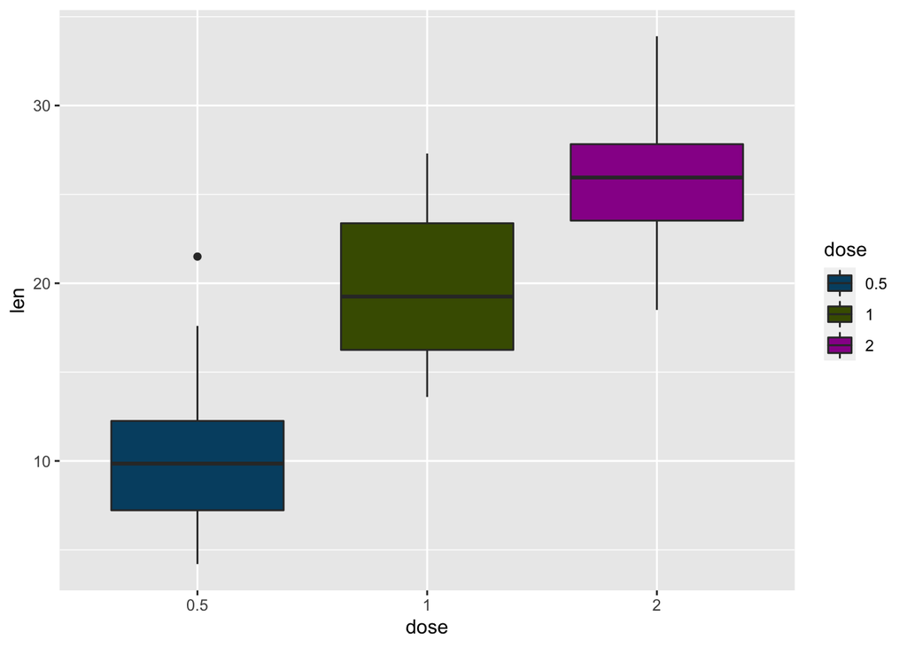

```r
my_plot +
  scale_fill_manual(values = c("#004f71", "#465a01", "#981d97"))
```

## Changing colors with `RColorBrewer`

That looks pretty nice, but we could spend an awful lot of time making tiny tweaks to color palettes by hand. Luckily Cynthia Brewer over at [ColorBrewer](http://colorbrewer2.org) has come up with some really good ones we can borrow! Let’s load the `RColorBrewer` library and check it out. **Note:** you might need to `install.packages('RColorBrewer')` if you’re running `R` on your laptop.

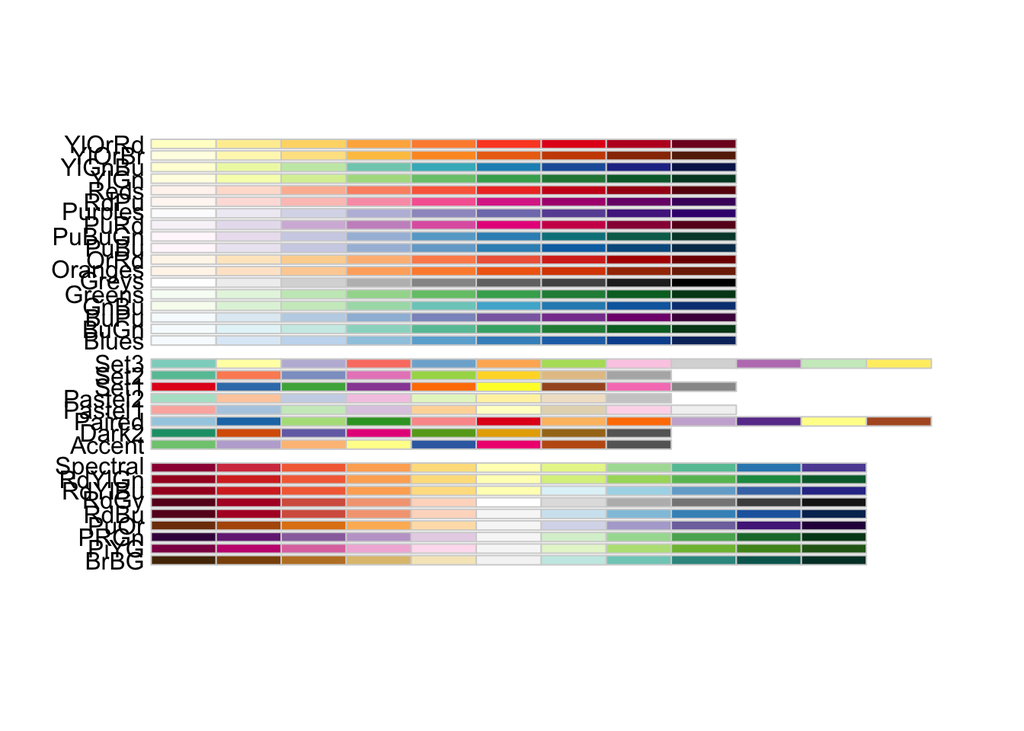

```r
library(RColorBrewer)
display.brewer.all()
```

Ooh, so many choices! We can now use these `palettes` along with `scale_fill_brewer()` to make perceptually-optimized plots:

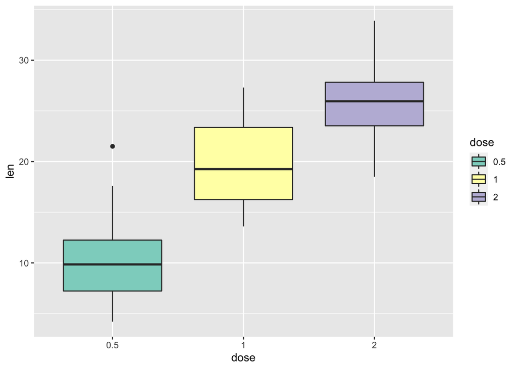

```r
my_plot +
  scale_fill_brewer(palette = "Set3")
```

2. Try out a few other color palettes!

```r
# Put your code here
```

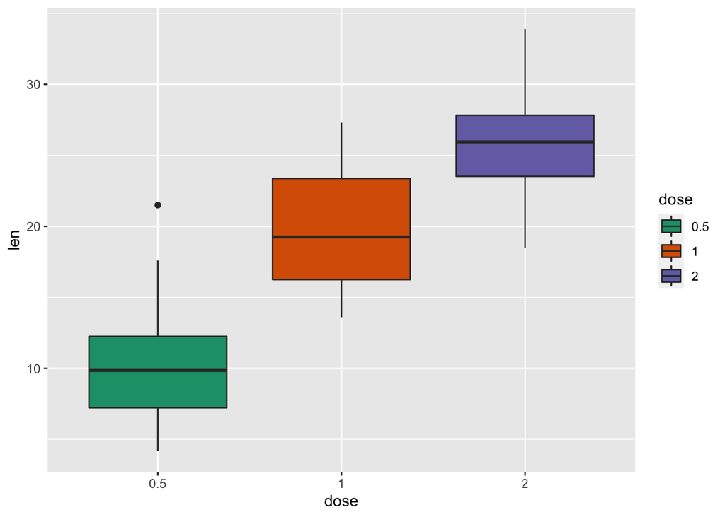

```r
# sample solution
my_plot +
  scale_fill_brewer(palette = "Dark2")
```

Let’s try another. Install the `nasaweather` package, and load it.

```r
#install.packages("nasaweather")
library(nasaweather)
```

To make the plot easier to read, we will first filter the `storms` data frame to include only storms from 1995.

```r
my_storms <- storms %>%
    filter(year == 1995)
```

Now, let’s plot the storms in `my_storms`, mapping x to longitude, y to latitude, and color to wind speed. We’ll also use a `facet_wrap()` to make small multiples according to the `name` of each storm.

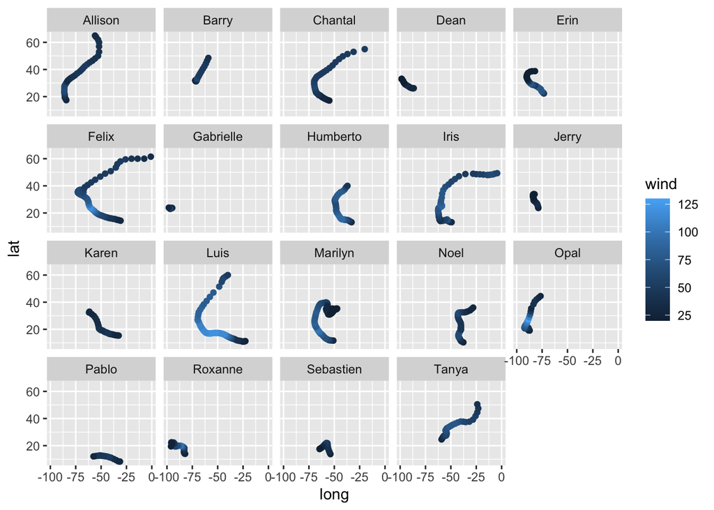

```r
ggplot(my_storms,
      aes(x = long,
          y = lat,
          color = wind)) +
  geom_point() +
  facet_wrap(~name)
```

3. Do you think a sequential or diverging color scheme is most appropriate for wind speed? Justify your answer.

## Stylizing using `ggthemes`

If we want even more control, we can use the `ggthemes` package to define not only the color palette, but the overall style of the plot as well. For example, if we want the mimic the style used by the graphic design team at [The Economist](http://www.economist.com), we could say:

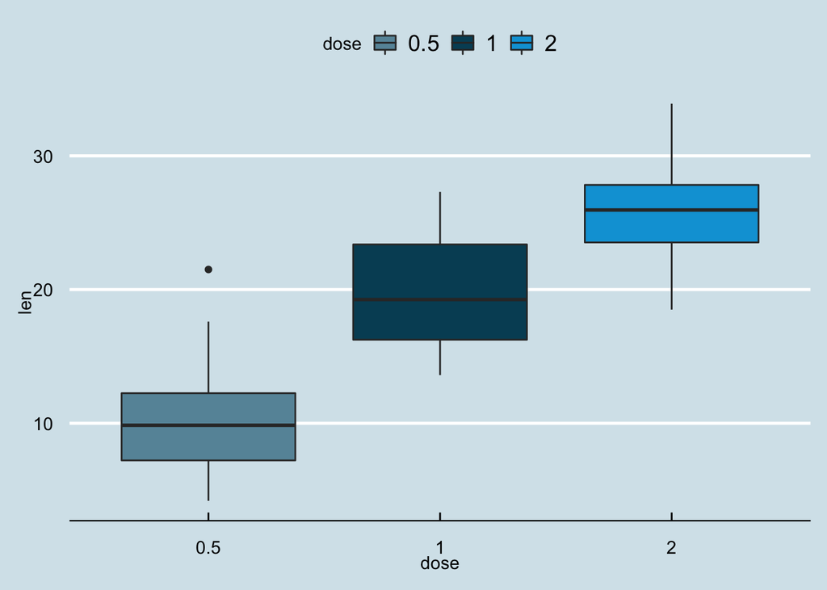

```r
library(ggthemes)
my_plot +
  theme_economist() +
  scale_fill_economist()
```

Notice how the background changed colors, the axes were re-styled, and the legend changed positions? You can read more about available `ggthemes` and `scales` [here](https://cran.r-project.org/web/packages/ggthemes/vignettes/ggthemes.html).

## Putting it all together

Now it’s time to get creative! There are many more datasets available in `R`. Let’s take a look at what we’ve got to play with:

```r
data()
```

You can learn more about any of the datasets by running `?<dataset>` at the console (replacing `<dataset>` with the name of the dataset).

4. Use `ggplot` to draw a plot of any dataset you like, and style it.  
   Try combining both a theme and a color palette.

```r
# Put your code here
```